# EDA

#### Regression Plot(Train):

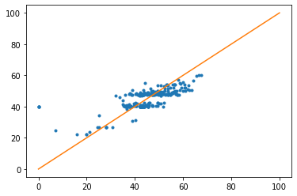

```python
y_pred_train = clf.predict(X_train)
#Plotting the graph for training set:
plt.plot(y_train,y_pred_train,'.')
a = np.linspace(0, 100, 10)
b = a
plt.plot(a, b)
plt.show()
```

#### Prediction Scores-R2, mean absolute error, root mean squared error, reggression plot and distribution plot:

```python
y_pred_rf = clf.predict(X_test)
score = r2_score(y_test,y_pred_rf)
score
```

```
0.49630778027865163
```

```python
from sklearn.metrics import mean_absolute_error
mae_rf = mean_absolute_error(y_test,y_pred_rf)
mae_rf
```

```
4.874634446670658
```

```python
from sklearn.metrics import mean_squared_error
rmse_rf = mean_squared_error(y_test,y_pred_rf,squared=False)
rmse_rf
```

```
6.8981645586587526
```

```python
print(f' Prediction scores: \n R2 score: {score},Root mean squared error: {rmse_rf},Mean absolute error: {mae_rf}')
```

```
 Prediction scores:
 R2 score: 0.49630778027865163,Root mean squared error: 6.8981645586587526,Mean absolute error: 4.874634446670658
```

[figure not shown]

```python
# Plotting the graph:
plt.plot(y_test, y_pred, '.')

# plot a line, a perfit predict would all fall on this line
a = np.linspace(0, 100, 10)
b = a
plt.plot(a, b)
plt.show()
```

[figure not shown]

```python
sns.distplot(y_test-y_pred)
plt.show()
```

#### After the scaling with multiple transformations. I was getting a good train and test R2 score and a good cross_val_score for exponential and square root transformations. There was some overfitting in the raw dataset. So, we are not using that. Square root transformation provided the best fit as well as cross_val_score. So, will be working with that.

### XG Boost

```python
from xgboost import XGBRegressor
```

#### Hyperparameter Tuning:

```python
# xgb = XGBRegressor()
# param_grid_xgboost = {

#                 'learning_rate': [0.3, 0.1, 0.05, 0.001],
#                 'max_depth': range(3,10,2),
#                 'n_estimators': [10,100,300,500],
#                 'gamma': [0,0.1,0.2,15,20],
#                 'min_child_weight': [8,9],
#                 'subsample': [0.8,0.9],
#                 'colsample_bytree': [0.8,0.9],
#                 'reg_lambda': [0, 0.001,0.01, 0.05],
#                 'reg_alpha': [0, 0.001, 0.01, 0.05]

#  }
```

```python
xgb = XGBRegressor()
param_grid_xgboost = {

                'learning_rate': [0.3, 0.1, 0.05, 0.001],
                'max_depth': range(3,10,2),
                'n_estimators': [10,100,300,500],
                'subsample': [0.7,0.8,0.9],
                'colsample_bytree': [0.7,0.8,0.9]
 }
```

```python
grid = GridSearchCV(estimator=xgb,param_grid=param_grid_xgboost,n_jobs=-1,cv=5,verbose=2)
grid.fit(X_train,y_train)
```

```
Fitting 5 folds for each of 576 candidates, totalling 2880 fits
```

```
GridSearchCV(cv=5,
             estimator=XGBRegressor(base_score=None, booster=None,
                                    colsample_bylevel=None,
                                    colsample_bynode=None,
                                    colsample_bytree=None, gamma=None,
                                    gpu_id=None, importance_type='gain',
                                    interaction_constraints=None,
                                    learning_rate=None, max_delta_step=None,
                                    max_depth=None, min_child_weight=None,
                                    missing=nan, monotone_constraints=None,
                                    n_estimators=100, n_jobs=...
                                    num_parallel_tree=None, random_state=None,
                                    reg_alpha=None, reg_lambda=None,
                                    scale_pos_weight=None, subsample=None,
                                    tree_method=None, validate_parameters=None,
                                    verbosity=None),
             n_jobs=-1,
             param_grid={'colsample_bytree': [0.7, 0.8, 0.9],
                         'learning_rate': [0.3, 0.1, 0.05, 0.001],
                         'max_depth': range(3, 10, 2),
                         'n_estimators': [10, 100, 300, 500],
                         'subsample': [0.7, 0.8, 0.9]},
             verbose=2)
```

```python
learning_rate = grid.best_params_['learning_rate']
max_depth = grid.best_params_['max_depth']
n_estimators = grid.best_params_['n_estimators']
subsample = grid.best_params_['subsample']
colsample_bytree = grid.best_params_['colsample_bytree']
```

```python
xgb = XGBRegressor(objective='reg:squarederror',learning_rate=learning_rate,max_depth=max_depth,n_estimators=n_estimators,
                  gamma=0,min_child_weight=8,subsample=subsample,colsample_bytree=colsample_bytree,n_jobs=-1)
xgb.fit(X_train, y_train)
```

```
XGBRegressor(base_score=0.5, booster='gbtree', colsample_bylevel=1,
             colsample_bynode=1, colsample_bytree=0.7, gamma=0, gpu_id=-1,
             importance_type='gain', interaction_constraints='',
             learning_rate=0.1, max_delta_step=0, max_depth=3,
             min_child_weight=8, missing=nan, monotone_constraints='()',
             n_estimators=300, n_jobs=-1, num_parallel_tree=1, random_state=0,
             reg_alpha=0, reg_lambda=1, scale_pos_weight=1, subsample=0.7,
             tree_method='exact', validate_parameters=1, verbosity=None)
```

```python
xgb.score(X_train,y_train)
```

```
0.7158611365413705
```

#### Regression Plot(Train):

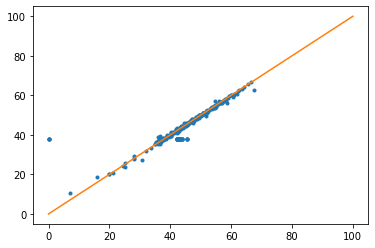

```python
y_pred_train = xgb.predict(X_train)
plt.plot(y_train,y_pred_train,'.')
a = np.linspace(0, 100, 5)
b = a
plt.plot(a, b)
plt.show()
```

#### Prediction Scores-R2, mean absolute error, root mean squared error, reggression plot and distribution plot:

```python
y_pred_xgb = xgb.predict(X_test)
score_xgb = r2_score(y_test,y_pred_xgb)
score_xgb
```

```
0.6106599181793939
```

```python
from sklearn.metrics import mean_absolute_error
mae_xgb = mean_absolute_error(y_test,y_pred_xgb)
mae_xgb
```

```
4.185482983636311
```

```python
from sklearn.metrics import mean_squared_error
mse_xgb = mean_squared_error(y_test,y_pred_xgb,squared=False)
mse_xgb
```

```
6.064786083021427
```

```python
print(f' Prediction scores: \n R2 score: {score_xgb},Root mean squared error: {mse_xgb},Mean absolute error: {mae_xgb}')
```

```
 Prediction scores:
 R2 score: 0.6106599181793939,Root mean squared error: 6.064786083021427,Mean absolute error: 4.185482983636311
```

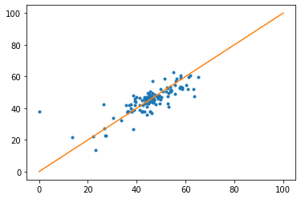

```python
# Plotting the graph:
plt.plot(y_test, y_pred_xgb, '.')

# plot a line, a perfit predict would all fall on this line
a = np.linspace(0,100,10)
b = a
plt.plot(a, b)
plt.show()
```

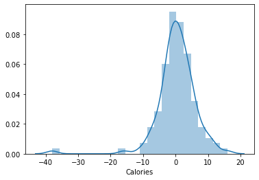

```python
sns.distplot(y_test-y_pred_xgb)
plt.show()
```

### Support Vector Regressor:

```python
from sklearn.svm import SVR
```

```python
svr = SVR()
svr.fit(X_train,y_train)
```

```
SVR()
```

```python
svr.score(X_train,y_train)
```

```
0.24476571051543927
```

#### Prediction Scores-R2, mean absolute error, root mean squared error and distribution plot:

```python
y_pred_svr = svr.predict(X_test)
score_svr = r2_score(y_test,y_pred_svr)
score_svr
```

```
0.2700983253697675
```

```python
from sklearn.metrics import mean_absolute_error
mae_svr = mean_absolute_error(y_test,y_pred_svr)
mae_svr
```

```
5.998333601861038
```

```python
from sklearn.metrics import mean_squared_error
rmse_svr = mean_squared_error(y_test,y_pred_svr,squared=False)
rmse_svr
```

```
8.303919094566234
```

```python
print(f' Prediction scores: \n R2 score: {score_svr},Root mean squared error: {rmse_svr},Mean absolute error: {mae_svr}')
```

```
 Prediction scores:
 R2 score: 0.2700983253697675,Root mean squared error: 8.303919094566234,Mean absolute error: 5.998333601861038
```

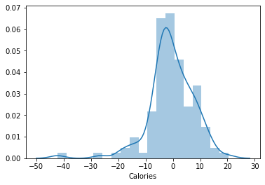

```python
sns.distplot(y_test-y_pred_svr)
plt.show()
```